# Solution

Juan Rossano

2026-03-25

#### Features

The variables included in this dataset are:

- **steps**: Number of steps taken in a 5-minute interval (missing values are coded as `NA`).
- **date**: Date in which the measurement was taken in YYYY-MM-DD format.
- **interval**: Identifier for the 5-minute interval in which measurement was taken.

### What Is the Mean Total Number of Steps Taken Per Day?

For this part of the assignment, missing values can be ignored.

1. Create a histogram of the total number of steps taken each day.
2. Calculate and report the **mean** and **median** of the total number of steps taken per day.

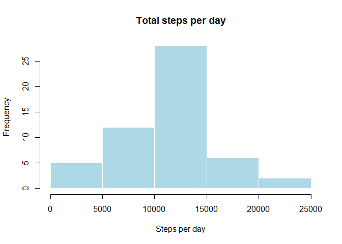

```r
total_steps_day <- aggregate(steps ~ date, data = activity, FUN = sum, na.rm = TRUE)

hist(total_steps_day$steps,
    main = "Total steps per day",
    xlab = "Steps per day",
    ylab = "Frequency",
    col = "lightblue",
    border = "white")
```

```r
mean_steps_day <- mean(total_steps_day$steps)
median_steps_day <- median(total_steps_day$steps)

mean_steps_day
```

```
## [1] 10766.19
```

```r
median_steps_day
```

```
## [1] 10765
```

### What Is the Average Daily Activity Pattern?

1. Create a time series plot (i.e., `type = "l"`) of the 5-minute interval (x-axis) and the average number of steps taken, averaged across all days (y-axis).
2. Which 5-minute interval, on average across all days in the dataset, contains the maximum number of steps?

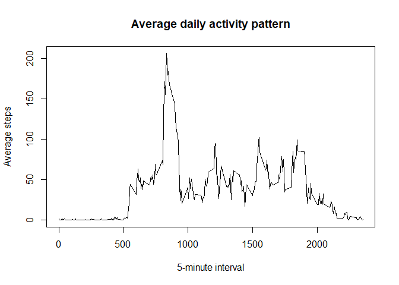

```r
avg_steps_interval <- aggregate(steps ~ interval, data = activity, FUN = mean, na.rm = TRUE)

plot(avg_steps_interval$interval,
    avg_steps_interval$steps,
    type = "l",
    xlab = "5-minute interval",
    ylab = "Average steps",
    main = "Average daily activity pattern")
```

```r
max_interval <- avg_steps_interval$interval[which.max(avg_steps_interval$steps)]
max_interval
```

```
## [1] 835
```

### Imputing Missing Values

Note that there are several days/intervals with missing values (coded as `NA`). The presence of missing days may introduce bias in some calculations or summaries of the data.

1. Calculate and report the total number of missing values in the dataset (i.e., the total number of rows with `NA`).
2. Design a strategy to fill in all missing values in the dataset. The strategy does not need to be complex. For example, you could use the mean/median for that day, or the mean for that 5-minute interval, etc.
3. Create a new dataset that is equal to the original one but with missing values filled in.
4. Create a histogram of the total number of steps taken each day and calculate and report the **mean** and **median** total number of steps taken per day. Do these values differ from the estimates in the first part of the assignment? What is the impact of imputing missing data on the estimates of the total daily number of steps?

```r
na_total <- sum(is.na(activity$steps))
na_total
```

```
## [1] 2304
```

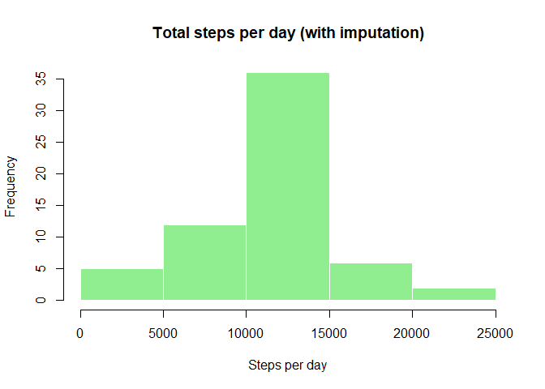

```r
# Strategy: impute each NA in steps with the mean of its 5-minute interval.
interval_means <- aggregate(steps ~ interval, data = activity, FUN = mean, na.rm = TRUE)

activity_filled <- activity
na_index <- is.na(activity_filled$steps)
activity_filled$steps[na_index] <- interval_means$steps[
    match(activity_filled$interval[na_index], interval_means$interval)
]

total_steps_day_filled <- aggregate(steps ~ date, data = activity_filled, FUN = sum)

hist(total_steps_day_filled$steps,
         main = "Total steps per day (with imputation)",
         xlab = "Steps per day",
         ylab = "Frequency",
         col = "lightgreen",
         border = "white")
```

```r
mean_steps_day_filled <- mean(total_steps_day_filled$steps)
median_steps_day_filled <- median(total_steps_day_filled$steps)

mean_steps_day_filled
```

```
## [1] 10766.19
```

```r
median_steps_day_filled
```

```
## [1] 10766.19
```

```r
cat("Mean without imputation:", mean_steps_day, "\n")
```

```
## Mean without imputation: 10766.19
```

```r
cat("Median without imputation:", median_steps_day, "\n")
```

```
## Median without imputation: 10765
```

```r
cat("Mean with imputation:", mean_steps_day_filled, "\n")
```

```
## Mean with imputation: 10766.19
```

```r
cat("Median with imputation:", median_steps_day_filled, "\n")
```

```
## Median with imputation: 10766.19
```

### Are There Differences in Activity Patterns Between Weekdays and Weekends?

For this part, the `weekdays()` function may be helpful. Use the dataset with missing values already filled in.

1. Create a new categorical variable in the dataset with two levels: “weekday” and “weekend”, indicating whether a given date is a weekday or a weekend day.
2. Create a panel plot containing a time series plot (i.e., `type = "l"`) of the 5-minute interval (x-axis) and the average number of steps taken, averaged for all weekday days or weekend days (y-axis).

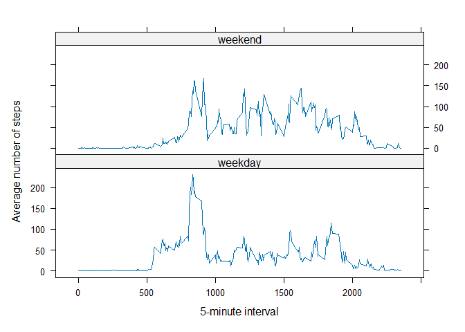

```r
library(lattice)

activity_filled$day_type <- ifelse(
    weekdays(activity_filled$date) %in% c("Saturday", "Sunday", "sábado", "domingo"),
    "weekend",
    "weekday"
)

activity_filled$day_type <- factor(activity_filled$day_type, levels = c("weekday", "weekend"))

avg_by_daytype <- aggregate(steps ~ interval + day_type,
                                                        data = activity_filled,
                                                        FUN = mean)

xyplot(steps ~ interval | day_type,
             data = avg_by_daytype,
             type = "l",
             layout = c(1, 2),
             xlab = "5-minute interval",
             ylab = "Average number of steps")
```